# Block course: R-tutorial for ecologists

## Two samples analysis

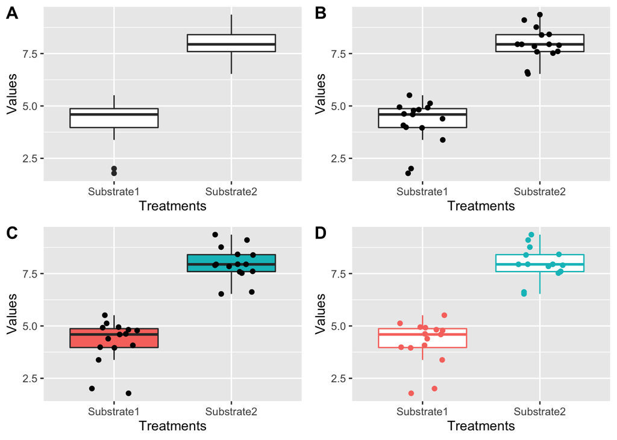

```r
## Visualize data
#install.packages("ggplot2")
#install.packages("cowplot")

library(ggplot2)
library(cowplot)

# Simple boxplots with different graphical options
p1=ggplot(DF,aes(x=Treatments, y=Values))+geom_boxplot()
# Simple boxplots with data points
p2=ggplot(DF,aes(x=Treatments, y=Values))+geom_boxplot(outlier.size = -1)+geom_jitter(width = 0.2)
# Simple boxplots colored
p3=ggplot(DF,aes(x=Treatments, y=Values, fill=Treatments))+geom_boxplot(outlier.size = -1)+ geom_jitter(width = 0.2)+theme(legend.position = "none")
# Simple boxplots with colored points
p4=ggplot(DF,aes(x=Treatments, y=Values, colour=Treatments))+geom_boxplot(outlier.size = -1)+ geom_jitter(width = 0.2)+theme(legend.position = "none")
plot_grid(p1,p2,p3,p4,labels = "AUTO",align = "v", axis = "l")
```

```r
# t-test two samples
t.test(DF$Values[DF$Treatments=="Substrate1"], DF$Values[DF$Treatments=="Substrate2"],var.equal = T) #Default setup: Only diff
```

```
##
##  Two Sample t-test
##
## data:  DF$Values[DF$Treatments == "Substrate1"] and DF$Values[DF$Treatments == "Substrate2"]
## t = -10.982, df = 28, p-value = 1.169e-11
## alternative hypothesis: true difference in means is not equal to 0
## 95 percent confidence interval:
##  -4.474736 -3.067906
## sample estimates:
## mean of x mean of y
##  4.192973  7.964294
```

```r
t.test(DF$Values[DF$Treatments=="Substrate1"], DF$Values[DF$Treatments=="Substrate2"],var.equal = T,alternative ="less")
```

```
##
##  Two Sample t-test
##
## data:  DF$Values[DF$Treatments == "Substrate1"] and DF$Values[DF$Treatments == "Substrate2"]
## t = -10.982, df = 28, p-value = 5.846e-12
## alternative hypothesis: true difference in means is less than 0
## 95 percent confidence interval:
##       -Inf -3.187159
## sample estimates:
## mean of x mean of y
##  4.192973  7.964294
```

```r
#Alternative hypothesis sample_a<sample_b or differences <0

t.test(DF$Values[DF$Treatments=="Substrate1"], DF$Values[DF$Treatments=="Substrate2"],var.equal = T, alternative ="greater")
```

```
##
##  Two Sample t-test
##
## data:  DF$Values[DF$Treatments == "Substrate1"] and DF$Values[DF$Treatments == "Substrate2"]
## t = -10.982, df = 28, p-value = 1
## alternative hypothesis: true difference in means is greater than 0
## 95 percent confidence interval:
##  -4.355483       Inf
## sample estimates:
## mean of x mean of y
##  4.192973  7.964294
```

```r
#Alternative hypothesis sample_a>sample_b or differences >0
```

## More than two samples

### ANOVA one-way

One way anovas considered continuous variables in discrete categories. For example, growth rates in different temperatures, respiration with different substrate as resources

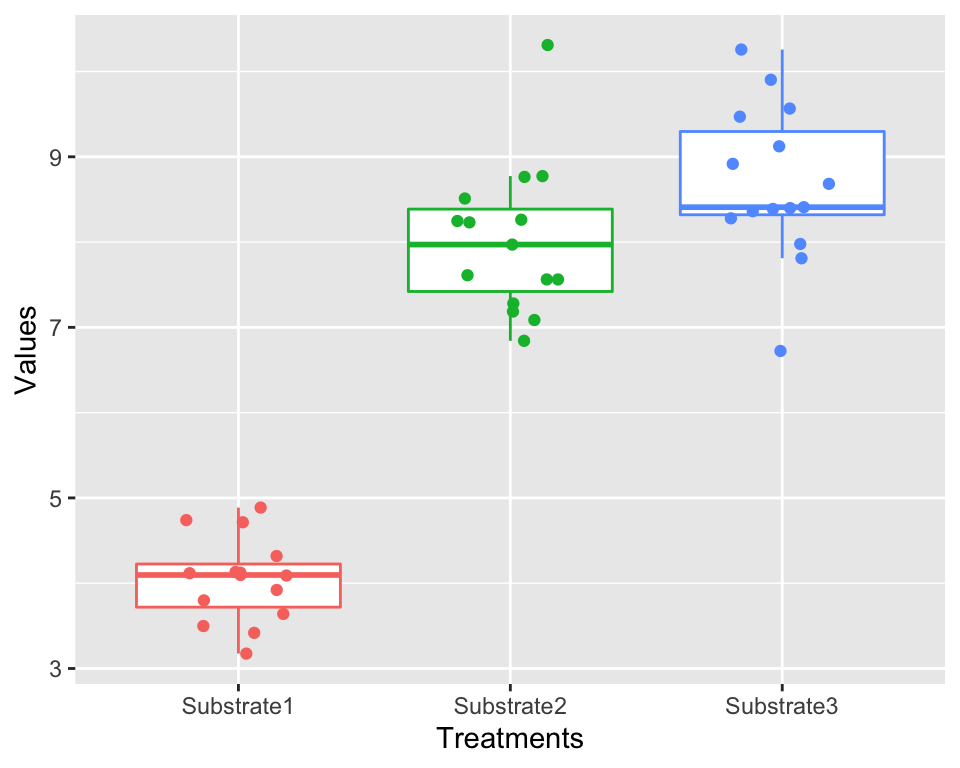

```r
#Generate testing data frames
set.seed(100)
DF=data.frame(Experiment=as.character("Test1"), # Experiment name
           Treatments=factor(rep(c("Substrate1","Substrate2","Substrate3"),each=15)), #Treatment description here 2 levels
           Values=c(rnorm(15,4,1),rnorm(15,8,1),rnorm(15,8.5,1))) # Theoretical response growth (mg L-1 h-1)
# Visualizing using ggplot2 data set
ggplot(DF,aes(x=Treatments, y=Values, colour=Treatments))+ geom_boxplot(outlier.size = -1)+ geom_jitter(width = 0.2)+ theme(legend.position = "none")
```

### Statistical analysis

Loading packages for analysis

```r
library(dplyr)
library(rstatix)
library(knitr)
library(kableExtra)
library(ggpubr)
```

### Assumptions and ANOVA

```r
#Normality of dataset
tapply(DF$Value,DF$Treatment,shapiro.test)
```

```
## $Substrate1
##
##  Shapiro-Wilk normality test
##
## data:  X[[i]]
## W = 0.9595, p-value = 0.6837
##
##
## $Substrate2
##
##  Shapiro-Wilk normality test
##
## data:  X[[i]]
## W = 0.91459, p-value = 0.1592
##
##
## $Substrate3
##
##  Shapiro-Wilk normality test
##
## data:  X[[i]]
## W = 0.96666, p-value = 0.806
```

```r
#Homogeneity of variance for each comparison (Treatment)
bartlett.test(Values~Treatments,data=DF)
```

```
##
##  Bartlett test of homogeneity of variances
##
## data:  Values by Treatments
## Bartlett's K-squared = 5.2431, df = 2, p-value = 0.07269
```

```r
#ANOVA one-way
anova1=DF%>%anova_test(Values ~ Treatments)
anova1
```

```
## ANOVA Table (type II tests)
##
##       Effect DFn DFd       F        p p<.05   ges
## 1 Treatments   2  42 155.318 3.93e-20     * 0.881
```

```r
res.tukey=DF%>%tukey_hsd(Values ~ Treatments)
res.tukey <- res.tukey %>% add_xy_position(x = "Treatments")
```

### Visualization: box plots with p-values

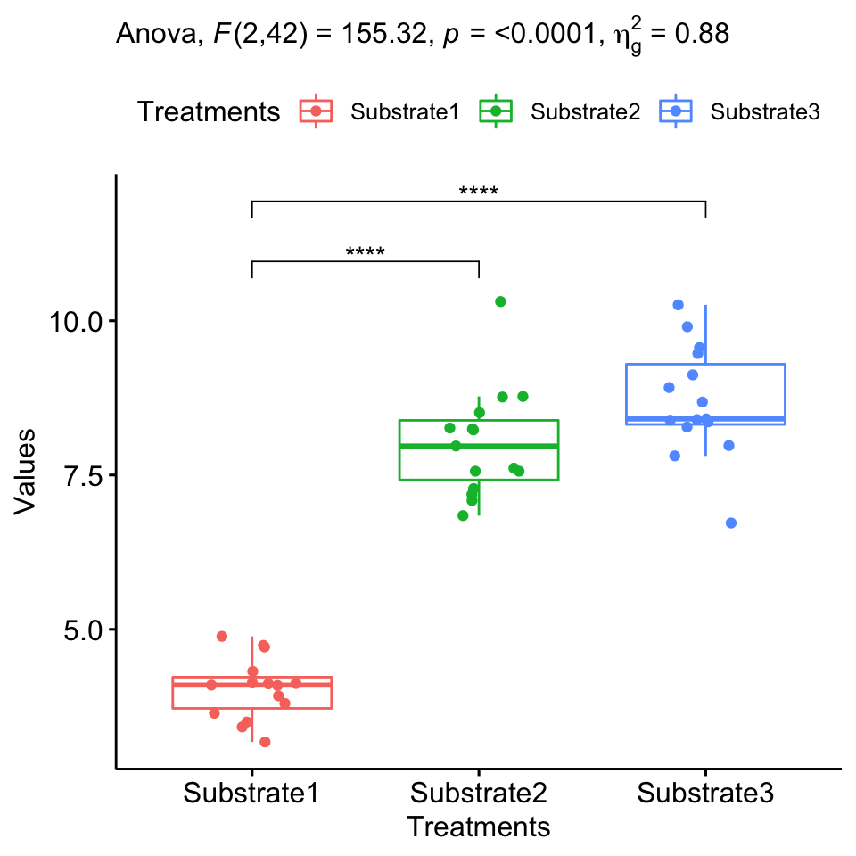

```r
ggboxplot(DF, x = "Treatments", y = "Values",color="Treatments",add = "jitter") +
  stat_pvalue_manual(res.tukey, hide.ns = TRUE) +
  labs(subtitle = get_test_label(anova1, detailed = TRUE))
```

## ANOVA two-ways

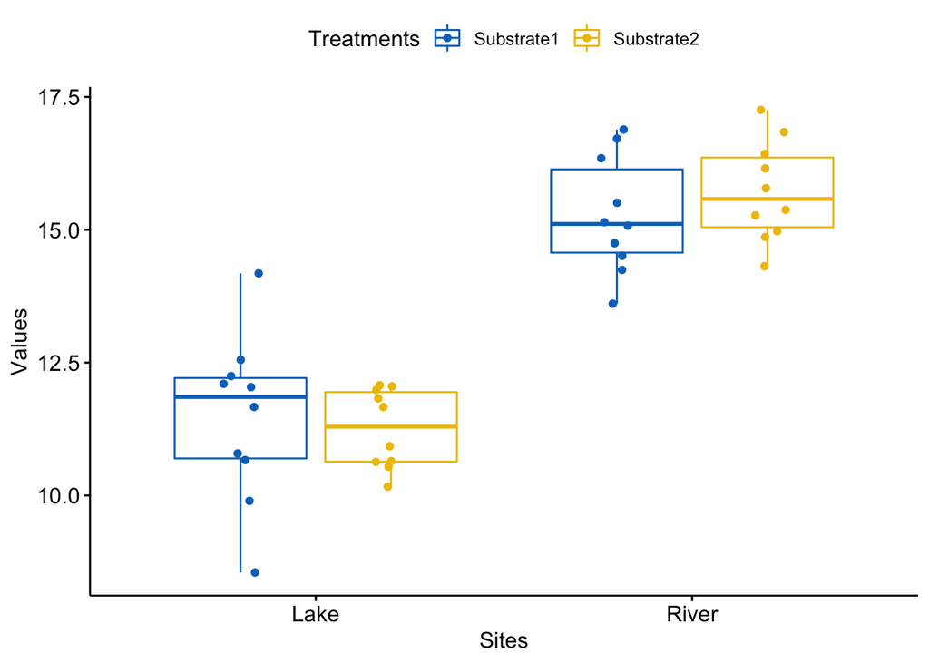

```r
#Generate testing data frames
DF=data.frame(Experiment=as.character("Experiment01"), # Experiment name
           Treatments=factor(rep(c("Substrate1","Substrate2"),each=20)), #Treatment description here 2 levels
           Sites=factor(rep(c("River","Lake"),each=10)),
           Values=c(rnorm(10,15,1.1),rnorm(10,11.5,1.5),
                    rnorm(10,16,1),rnorm(10,11,1.2))) # Theoretical response growth (mg L-1 h-1)

# Visualizing data set
bxp <-ggboxplot(DF, x= "Sites", y = "Values",add = "jitter",
  color = "Treatments", palette = "jco")
bxp
```

## Assumptions and ANOVA

```r
#Normality of dataset
tapply(DF$Value,interaction(DF$Treatment,DF$Sites),shapiro.test)
```

```
## $Substrate1.Lake
##
##  Shapiro-Wilk normality test
##
## data:  X[[i]]
## W = 0.96995, p-value = 0.8904
##
##
## $Substrate2.Lake
##
##  Shapiro-Wilk normality test
##
## data:  X[[i]]
## W = 0.86347, p-value = 0.08384
##
##
## $Substrate1.River
##
##  Shapiro-Wilk normality test
##
## data:  X[[i]]
## W = 0.95289, p-value = 0.7028
##
##
## $Substrate2.River
##
##  Shapiro-Wilk normality test
##
## data:  X[[i]]
## W = 0.97525, p-value = 0.9348
```

```r
#Homogeneity of variance for each comparison (Treatment)
bartlett.test (Values~interaction(Treatments,Sites),data=DF)
```

```
##
##  Bartlett test of homogeneity of variances
##
## data:  Values by interaction(Treatments, Sites)
## Bartlett's K-squared = 5.2399, df = 3, p-value = 0.155
```

```r
#ANOVA one-way
anova2=DF%>%anova_test(Values ~ Treatments*Sites)
anova2
```

```
## ANOVA Table (type II tests)
##
##             Effect DFn DFd       F        p p<.05   ges
## 1       Treatments   1  36   0.104 7.49e-01       0.003
## 2            Sites   1  36 135.988 8.78e-14     * 0.791
## 3 Treatments:Sites   1  36   0.873 3.56e-01       0.024
```

From the results above, What we can say about the main effects? Where are the differences among groups?

```r
DF$index=paste0(DF$Treatments,DF$Sites)
res.tukey=DF%>%
  group_by(Sites)%>%
tukey_hsd(Values ~ Treatments)
#Add position for plots
```

# Correlations

[figure not shown]

```r
DF2=data.frame(int.explorer=seq(25,95,length.out=26)+rnorm(26,1,2),
               USA.murders=seq(10000,20000,length.out=26)+rnorm(26,1000,200),
               year=2020:1995)
#Time series
ggplot(DF2)+geom_bar(aes(year,USA.murders),stat="identity",fill="blue")+
    geom_line(aes(x=year, y=200*int.explorer),stat="identity",color="red",size=2)+
    labs(title= "Murders in USA vs use of Internet Explorer", x="Year",y="Murders per year")+
    scale_y_continuous(sec.axis=sec_axis(~.*0.02,name="Percentage Use Internet Explorer"))
```

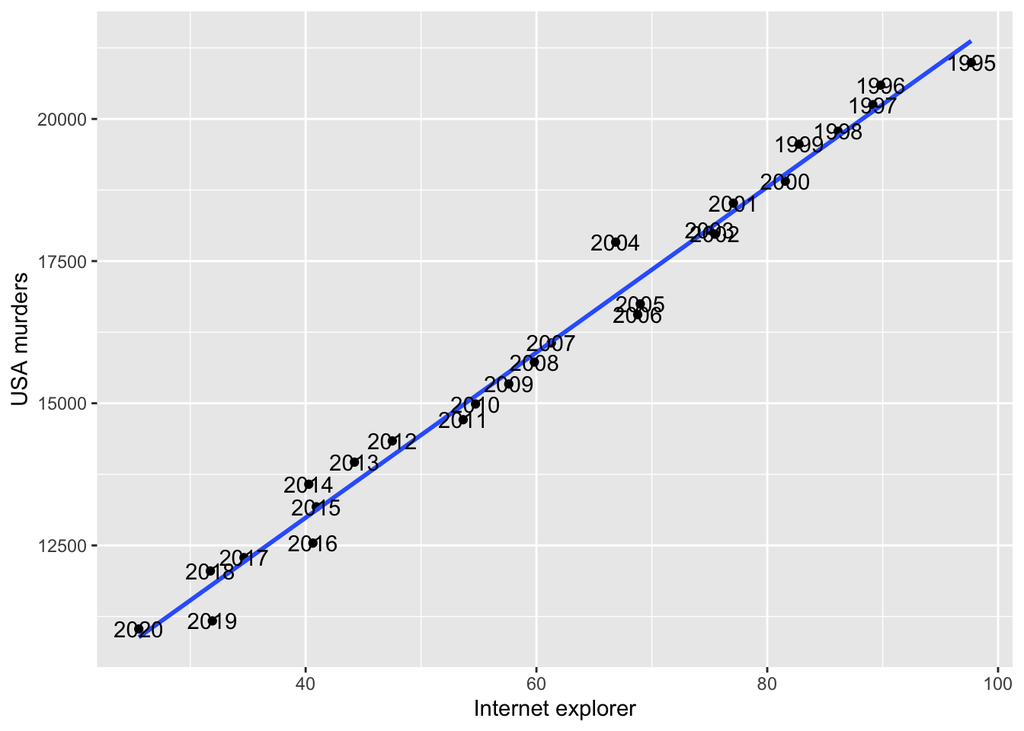

```r
# Correlation between variables
ggplot(data=DF2, aes(int.explorer,USA.murders))+labs(x="Internet explorer",y="USA murders")+
  geom_point()+geom_smooth(method="lm",se=F)+geom_text(aes(label=year))
```

```r
#Results correlations by Species
cor.test(~int.explorer+USA.murders,data=DF2,method = "pearson")
```

```
##
##  Pearson's product-moment correlation
##
## data:  int.explorer and USA.murders
## t = 40.084, df = 24, p-value < 2.2e-16
## alternative hypothesis: true correlation is not equal to 0
## 95 percent confidence interval:
##  0.9833521 0.9967317
## sample estimates:
##      cor
## 0.992614
```

# Multivariate Statistic

In the nature we usually observed many populations living together in a limited space with limited resources. For many years researcher have studied what are the rules governing, community composition changes

# Principal component analysis (PCA)

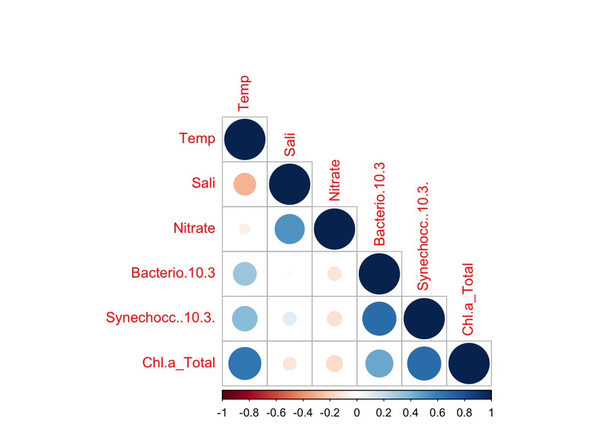

```r
rm(list=ls())
library(corrplot)
library(readxl)
D<-read_excel("../data/Base Datos CDOM 2018.xls",sheet = "Data_completa_sub_pca")

D<-data.frame(D)
M <- cor(na.omit(D[,12:17]),method="pearson")
corrplot(M, method = "circle",type = "lower")
```

```r
symnum(clS <- cor(na.omit(D[,12:17]),method='pearson'))
```

```
##                  T Sl N B S. C
## Temp             1
## Sali               1
## Nitrate            .  1
## Bacterio.10.3    .      1
## Synechocc..10.3. .      , 1
## Chl.a_Total      ,      . ,  1
## attr(,"legend")
## [1] 0 ' ' 0.3 '.' 0.6 ',' 0.8 '+' 0.9 '*' 0.95 'B' 1
```

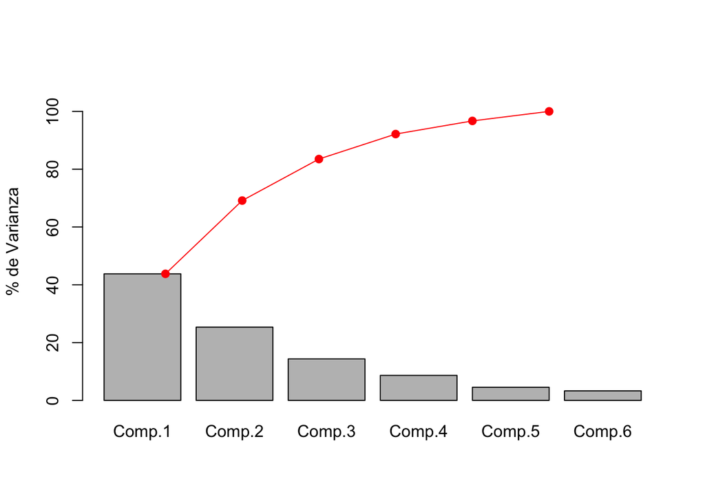

```r
##############################################################
naD<-na.omit(D)
local<-naD[,1]

pc1<-princomp(naD[,12:17],cor=T)
## Similar, but different:
## The standard deviations differ by a factor of sqrt(49/50)

var100<-pc1$sd^2/sum(pc1$sd^2)*100
varacum<-cumsum(var100)

barplot(var100,ylim=c(0,110),ylab="% de Varianza")
points(varacum,col="red",type="p",pch=19)
lines(varacum,col="red",type="l",pch=19)
```

```r
summary(pc1)
```

```
## Importance of components:
##                           Comp.1    Comp.2    Comp.3     Comp.4     Comp.5
## Standard deviation     1.6210421 1.2333142 0.9282499 0.72030555 0.52250543
## Proportion of Variance 0.4379629 0.2535106 0.1436080 0.08647335 0.04550199
## Cumulative Proportion  0.4379629 0.6914735 0.8350815 0.92155487 0.96705686
##                            Comp.6
## Standard deviation     0.44458843
## Proportion of Variance 0.03294314
## Cumulative Proportion  1.00000000
```

```r
loadings(pc1)  # note that blank entries are small but not zero
```

```
##
## Loadings:
##                  Comp.1 Comp.2 Comp.3 Comp.4 Comp.5 Comp.6
## Temp              0.441  0.133  0.650         0.566  0.192
## Sali             -0.157 -0.707 -0.110 -0.402  0.531 -0.142
## Nitrate          -0.196 -0.586  0.538  0.393 -0.414
## Bacterio.10.3     0.450 -0.220 -0.394  0.661  0.163 -0.360
## Synechocc..10.3.  0.508 -0.295 -0.269 -0.161 -0.231  0.710
## Chl.a_Total       0.531         0.219 -0.460 -0.383 -0.554
##
##                Comp.1 Comp.2 Comp.3 Comp.4 Comp.5 Comp.6
## SS loadings     1.000  1.000  1.000  1.000  1.000  1.000
## Proportion Var  0.167  0.167  0.167  0.167  0.167  0.167
## Cumulative Var  0.167  0.333  0.500  0.667  0.833  1.000
```

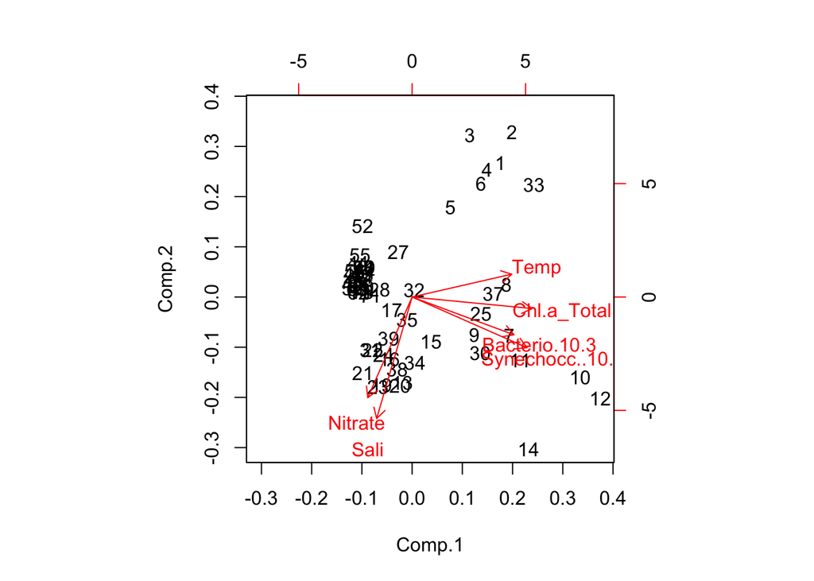

```r
biplot(pc1)
```

```r
pc1$loadings
```

```
##
## Loadings:
##                  Comp.1 Comp.2 Comp.3 Comp.4 Comp.5 Comp.6
## Temp              0.441  0.133  0.650         0.566  0.192
## Sali             -0.157 -0.707 -0.110 -0.402  0.531 -0.142
## Nitrate          -0.196 -0.586  0.538  0.393 -0.414
## Bacterio.10.3     0.450 -0.220 -0.394  0.661  0.163 -0.360
## Synechocc..10.3.  0.508 -0.295 -0.269 -0.161 -0.231  0.710
## Chl.a_Total       0.531         0.219 -0.460 -0.383 -0.554
##
##                Comp.1 Comp.2 Comp.3 Comp.4 Comp.5 Comp.6
## SS loadings     1.000  1.000  1.000  1.000  1.000  1.000
## Proportion Var  0.167  0.167  0.167  0.167  0.167  0.167
## Cumulative Var  0.167  0.333  0.500  0.667  0.833  1.000
```

```r
pc1$scores
```

```
##         Comp.1      Comp.2      Comp.3      Comp.4      Comp.5        Comp.6
## 1   2.18603490  2.52914568  1.21427001  0.55311325  0.50895356  0.4112126311
## 2   2.47282185  3.11910813  1.87358884 -0.04646565 -0.65430649 -0.3945844328
## 3   1.43223453  3.05298411  1.49526098  0.57380065 -0.24481475  0.8400424571
## 4   1.85780458  2.40340863  1.21647589 -0.39873914 -0.12078606 -0.1207636999
## 5   0.95121109  1.69784640  1.34353470  0.64271938  0.22198830  0.3233583031
## 6   1.70778115  2.13997397  1.23688398  0.28245408  0.65756624  0.5893167107
## 7   2.40813115 -0.72869698 -0.67458064 -0.81877150  0.66076058  1.1050345513
## 8   2.33869690  0.23543796  1.18668183 -2.50882012 -0.00194248 -1.6937552083
## 9   1.54106269 -0.71406594  0.56360158 -0.97076111  0.27651860 -0.0380813692
## 10  4.16603277 -1.51779802 -1.15642565 -0.44712567  0.06743284 -0.5640617867
## 11  2.67548888 -1.18550147 -0.87123546 -0.41072979  0.44834564  0.6203152291
## 12  4.66660964 -1.91423132 -1.11963811 -1.04575424 -0.41415642  1.0130395161
## 13 -0.24221085 -1.62063494  1.48945776 -0.02826256 -0.36216584 -0.3540621877
## 14  2.88379195 -2.86647958  0.13179117 -0.50185208 -1.38515510  0.9274379810
```

[output cut: 45 more lines]

```r
pc1$sdev
```

```
##    Comp.1    Comp.2    Comp.3    Comp.4    Comp.5    Comp.6
## 1.6210421 1.2333142 0.9282499 0.7203056 0.5225054 0.4445884
```

```r
pc1$center
```

```
##             Temp             Sali          Nitrate    Bacterio.10.3
##        9.3728201       30.9560451       14.2199558      302.5314989
## Synechocc..10.3.      Chl.a_Total
##        7.4289985        0.5183287
```

```r
pc1$data
```

# Beautiful PCA

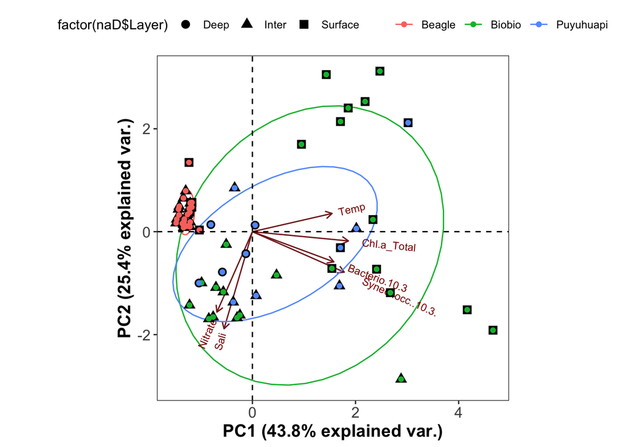

```r
library(devtools)
install_github("vqv/ggbiplot")

library(ggbiplot)

g <- ggbiplot(pc1, obs.scale = 1, var.scale =1, size=5,
              groups = naD$Region,ellipse=T)
g <- g + scale_color_discrete(name = '')#+ xlim(-4.5,4.5)+ ylim(-4.5,4.5)
g <- g + theme_bw()+theme(panel.grid.major = element_blank(), panel.grid.minor = element_blank())
g <- g+theme(legend.direction = "horizontal",legend.position = "top")
g <- g+theme(axis.text=element_text(size=12),axis.title=element_text(size=14,face="bold"))
g <-g+geom_point(aes(shape=factor(naD$Layer)), size = 3)
g <-g+geom_point(aes(colour=factor(naD$Region)))
g <-g+geom_vline(xintercept = 0,linetype="dashed")+
geom_hline(yintercept = 0,linetype="dashed")
g
```

# Biological data

```r
rm(list=ls())
library(reshape2)
library(ggplot2)
library(gridExtra)
library(vegan)
library(RColorBrewer)
library(phyloseq)

# Colorblind palette
cbp1 <- c("#999999","#FFDB6D", "#E69F00", "#56B4E9", "#009E73",
         "#F0E442", "#0072B2", "#D55E00", "#CC79A7","#293352")

# Load datasets
asv <- read.table('../data/dada.counts.ASV.1.txt', sep="\t" ,header = TRUE,row.names = 1) #Load raw count table
tax <- read.table('../data/dada.Taxonomy.ASV.tab', sep="\t" ,header = TRUE)

#Rarefaction of samples
raremax <- min(rowSums(asv))
Srare <- rrarefy(asv, raremax)
asv=t(Srare)
asv=prop.table(asv,2)
asv<- asv*100 #multiply by 100 to get % data
asv=data.frame(asv)
ASV=rownames(asv)
asv=cbind(ASV,asv)


# Combine relative count-table with taxonomic information
df1<-(data.frame(tax, asv))
df1=df1[,c("Kingdom",  "Phylum" ,  "Class" ,   "Order"  ,  "Family"  ,"Genus" ,"ASV", "SOLA1","SOLA2", "SOLA3","Sea1","Sea2","Sea3","SM1","SM2", "SM3","SS1","SS2","SS3")]
```

```r
#aggregate counts by order
df2<-aggregate(cbind(Sea1,Sea2,Sea3,
                     SM1,SM2,SM3,
                     SOLA1,SOLA2,SOLA3,
                     SS1,SS2,SS3) ~ Order,
               data = df1, sum, na.rm = TRUE)

order <- df2[,1] #vector with orders
rownames(df2) <- df2[,1] #row names
df2<-df2[,-1] #remove column with orders and keep only abundance data
colSums(df2) #test the sum of columns to see if values close to 1 are reached
```

```
##     Sea1     Sea2     Sea3      SM1      SM2      SM3    SOLA1    SOLA2
## 99.90445 94.48193 98.05315 99.59988 99.25351 99.71932 88.52792 92.12302
##    SOLA3      SS1      SS2      SS3
## 88.70708 99.78501 99.75515 99.83876
```

```r
agg=df2
#change format of agg to samples by column
agg<-as.data.frame(agg)
rownames(agg) <- order #add order information
agg$Sum.agg<-rowSums(agg) # add column with counts across treatments for all orders

#test how many of the orders (ranked by abundance) are meaningful to not include to many orders but reach values possibly close to 1
colSums(agg[with(agg, order(-Sum.agg)),][1:10,])
```

```
##       Sea1       Sea2       Sea3        SM1        SM2        SM3      SOLA1
##   99.57599   92.75605   96.62586   97.32457   98.81159   98.99672   84.47895
##      SOLA2      SOLA3        SS1        SS2        SS3    Sum.agg
##   89.30427   84.84324   99.42669   99.22962   99.20573 1140.57928
```

```r
#select the most abundant orders (top 10)
agg10<-agg[with(agg, order(-Sum.agg)),][1:10,1:12]
agg10$order <-rownames(agg10)
```

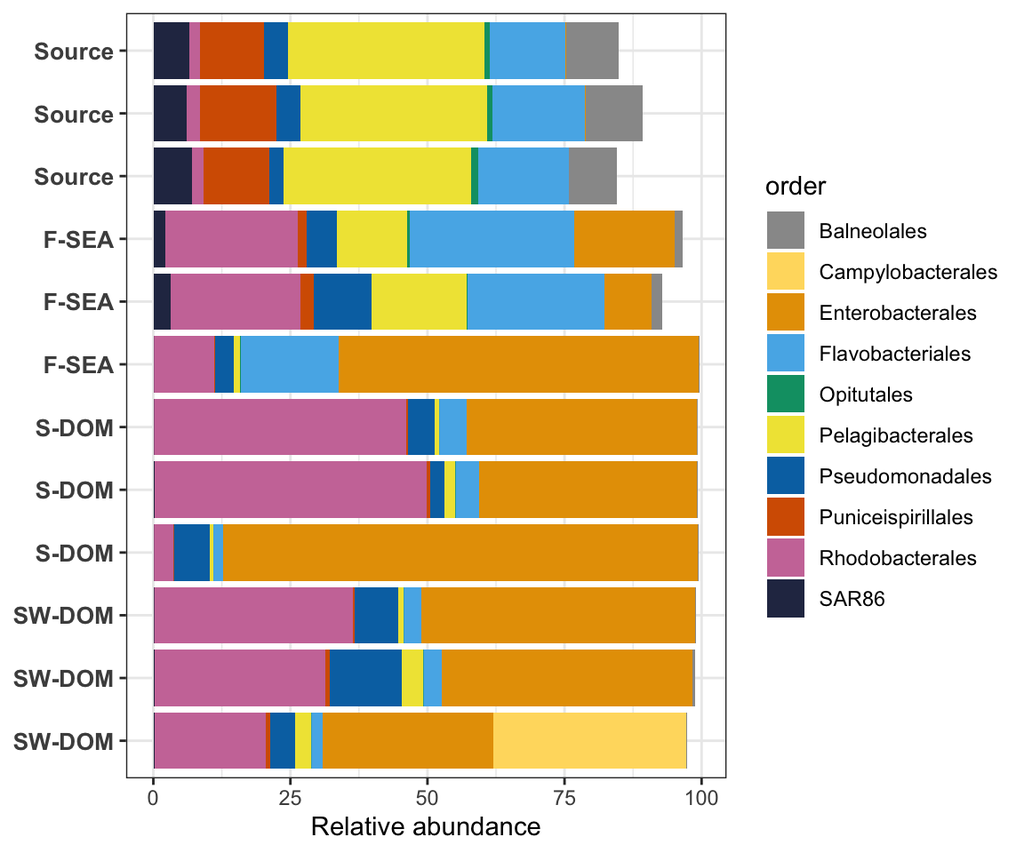

```r
#convert to long format
agg10.long<-melt(agg10, id.vars='order', variable.name = "treat")

positions <- c("SW-DOM","SW-DOM","SW-DOM",
               'S-DOM',"S-DOM","S-DOM",
               "F-SEA","F-SEA","F-SEA",
               "Source","Source","Source")

getPalette = colorRampPalette(brewer.pal(10, "Paired"))

plot0<-ggplot(agg10.long, aes(x = treat, y = value, fill = order)) +
  geom_bar(stat = "identity")+scale_fill_manual(values = cbp1)+
  scale_x_discrete(limits=c("SM1","SM2","SM3","SS1","SS2","SS3", "Sea1","Sea2","Sea3","SOLA1","SOLA2","SOLA3"),
                   labels =positions)+labs(y="Relative abundance", x=NULL)+
  theme_bw()+  theme(axis.text.y =element_text(face="bold",size=10,angle=0,hjust = 1)) +coord_flip()

plot0
```

## Principal coordinate analysis (PCOA)

Multidimensional scaling have been used to represent in a 2 or 3D space the multivariate changes in community composition. Imagine every species in a population is a single variable, then multidimensional scaling allow to reduce dimensions to the most important ones. This reduction is based in the weight of the variance explained by the relative abundance of the species.

```r
########################## PCoA
ps.rel = otu_table(df1[,8:19], taxa_are_rows = TRUE)
#ggplot
#all samples
ord.pcoa<- ordinate(ps.rel, method="PCoA", distance="bray")
ord.nmds<- ordinate(ps.rel, method="NMDS", distance="bray",autotransform=T)
```

```
## Square root transformation
## Wisconsin double standardization
## *** Solution reached
```

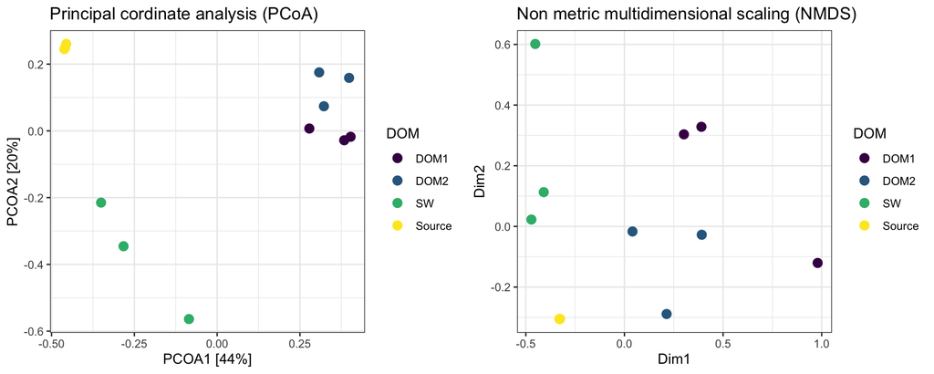

```r
df.ord.pcoa=data.frame(pco1=ord.pcoa$vectors[,1],pco2=ord.pcoa$vectors[,2],
                            DOM=c("Source","Source","Source",
                                  "SW","SW","SW",
                                  "DOM2","DOM2","DOM2",
                                  "DOM1","DOM1","DOM1"))
df.ord.nmds<-data.frame(pco1=ord.nmds$points[,1],pco2=ord.nmds$points[,2])
df.ord.nmds$DOM=df.ord.pcoa$DOM
# Ordering factors
df.ord.pcoa$DOM=ordered(df.ord.pcoa$DOM,levels=c("DOM1","DOM2","SW", "Source"))
df.ord.nmds$DOM=ordered(df.ord.pcoa$DOM,levels=c("DOM1","DOM2","SW", "Source"))

p2=ggplot(df.ord.pcoa,aes(x=pco1, y=pco2,colour=DOM))+
  geom_point(size=3)+
    labs(title="Principal cordinate analysis (PCoA)",x=paste0("PCOA1 [",round(ord.pcoa$values[2][1,]*100,0),"%]") ,
       y=paste0("PCOA2 [",round(ord.pcoa$values[2][2,]*100,0),"%]"))+
  theme_bw()

p3=ggplot(df.ord.nmds,aes(x=pco1, y=pco2,colour=DOM))+
  geom_point(size=3)+labs(title="Non metric multidimensional scaling (NMDS)",x="Dim1",y="Dim2")+
  theme_bw()

plot_grid(p2,p3)
```